# ¿Quién justifica qué? El rol del sentido de injusticia en las justificaciones de violencia en contexto de protesta

Martin Venegas Márquez

31/05/2022

# Introducción

El presente documento corresponde al procesamiento de los datos la tesis llamada “¿Quién justifica qué? El rol del sentido de injusticia en las justificaciones de violencia en contexto de protesta”.

# Procesamiento

## JV Control Social: Carabineros reprimen marchas

### Descriptivo

Justificacion de violencia: Carabineros reprima marchas (2019) (x) # total N=3417 valid N=3417 mean=-1.30 sd=49.93

## Value | Label | N | Raw % | Valid % | Cum. %

-999 | No Responde (no leer) | 3 | 0.09 | 0.09 | 0.09 -888 | No Sabe (no leer) | 7 | 0.20 | 0.20 | 0.29 1 | Nunca se justifica | 2664 | 77.96 | 77.96 | 78.26 2 | Pocas veces se justifica | 318 | 9.31 | 9.31 | 87.56 3 | Algunas veces se justifica | 268 | 7.84 | 7.84 | 95.41 4 | Muchas veces se justifica | 109 | 3.19 | 3.19 | 98.60 5 | Siempre se justifica | 48 | 1.40 | 1.40 | 100.00 | | 0 | 0.00 | |

### Recodificación

### Descriptivo final

Justificacion de violencia: Carabineros reprima marchas (2019) (x) # total N=3417 valid N=3407 mean=1.40 sd=0.87

## Value | Label | N | Raw % | Valid % | Cum. %

```
1 |         Nunca se justifica | 2664 | 77.96 |   78.19 |  78.19
2 |   Pocas veces se justifica |  318 |  9.31 |    9.33 |  87.53
3 | Algunas veces se justifica |  268 |  7.84 |    7.87 |  95.39
4 |  Muchas veces se justifica |  109 |  3.19 |    3.20 |  98.59
5 |       Siempre se justifica |   48 |  1.40 |    1.41 | 100.00
```

| | 10 | 0.29 | | Justificación violencia control social: Carabineros reprime marchas (x) # total N=3417 valid N=3407 mean=1.40 sd=0.87

## Value | N | Raw % | Valid % | Cum. %

Nunca se justifica | 2664 | 77.96 | 78.19 | 78.19 Pocas veces se justifica | 318 | 9.31 | 9.33 | 87.53 Algunas veces se justifica | 268 | 7.84 | 7.87 | 95.39 Muchas veces se justifica | 109 | 3.19 | 3.20 | 98.59 Siempre se justifica | 48 | 1.40 | 1.41 | 100.00 | 10 | 0.29 | |

## JV Control Social: Carabineros desalojan tomas

### Descriptivo

NULL

### Recodificación

### Descriptivo final

Justificacion de violencia: Carabineros desaloje liceos en toma (2019) (x) # total N=3417 valid N=3391 mean=1.69 sd=1.07

## Value | Label | N | Raw % | Valid % | Cum. %

```
1 |         Nunca se justifica | 2145 | 62.77 |   63.26 |  63.26
2 |   Pocas veces se justifica |  549 | 16.07 |   16.19 |  79.45
3 | Algunas veces se justifica |  424 | 12.41 |   12.50 |  91.95
4 |  Muchas veces se justifica |  161 |  4.71 |    4.75 |  96.70
5 |       Siempre se justifica |  112 |  3.28 |    3.30 | 100.00
```

| | 26 | 0.76 | | Justificación violencia control social: Carabineros desaloja liceos en toma (x) # total N=3417 valid N=3391 mean=1.69 sd=1.07

## Value | N | Raw % | Valid % | Cum. %

Nunca se justifica | 2145 | 62.77 | 63.26 | 63.26 Pocas veces se justifica | 549 | 16.07 | 16.19 | 79.45 Algunas veces se justifica | 424 | 12.41 | 12.50 | 91.95 Muchas veces se justifica | 161 | 4.71 | 4.75 | 96.70 Siempre se justifica | 112 | 3.28 | 3.30 | 100.00 | 26 | 0.76 | |

## JV Cambio Social: Estudiantes tiran piedras

### Descriptivo

Justificacion de violencia: Estudiantes tiren piedras (2019) (x) # total N=3417 valid N=3417 mean=-1.78 sd=54.91

## Value | Label | N | Raw % | Valid % | Cum. %

-999 | No Responde (no leer) | 4 | 0.12 | 0.12 | 0.12 -888 | No Sabe (no leer) | 8 | 0.23 | 0.23 | 0.35 1 | Nunca se justifica | 2554 | 74.74 | 74.74 | 75.10 2 | Pocas veces se justifica | 361 | 10.56 | 10.56 | 85.66 3 | Algunas veces se justifica | 285 | 8.34 | 8.34 | 94.00 4 | Muchas veces se justifica | 129 | 3.78 | 3.78 | 97.78 5 | Siempre se justifica | 76 | 2.22 | 2.22 | 100.00 | | 0 | 0.00 | |

### Recodificación

### Descriptivo final

Justificacion de violencia: Estudiantes tiren piedras (2019) (x) # total N=3417 valid N=3405 mean=1.48 sd=0.96

## Value | Label | N | Raw % | Valid % | Cum. %

```
1 |         Nunca se justifica | 2554 | 74.74 |   75.01 |  75.01
2 |   Pocas veces se justifica |  361 | 10.56 |   10.60 |  85.61
3 | Algunas veces se justifica |  285 |  8.34 |    8.37 |  93.98
4 |  Muchas veces se justifica |  129 |  3.78 |    3.79 |  97.77
5 |       Siempre se justifica |   76 |  2.22 |    2.23 | 100.00
```

| | 12 | 0.35 | | Justificación violencia cambio social: Estudiantes tiren piedras (x) # total N=3417 valid N=3405 mean=1.48 sd=0.96

## Value | N | Raw % | Valid % | Cum. %

Nunca se justifica | 2554 | 74.74 | 75.01 | 75.01 Pocas veces se justifica | 361 | 10.56 | 10.60 | 85.61 Algunas veces se justifica | 285 | 8.34 | 8.37 | 93.98 Muchas veces se justifica | 129 | 3.78 | 3.79 | 97.77 Siempre se justifica | 76 | 2.22 | 2.23 | 100.00 | 12 | 0.35 | |

## Just. Dist: Salario percibido CEO

### Descriptivo

| var | label | n | NA.prc | mean | sd | range |
| --- | --- | --- | --- | --- | --- | --- |
| dd | dd | 3417 | 0 | 25140238 | 51439466 | 500000999 (-999-5e+08) |

|  | Overall (N=3417) |
| --- | --- |
| salario_perc_ceo |  |
| Mean (SD) | 25100000 (51400000) |
| Median [Min, Max] | 11000000 [-999, 500000000] |

### Recodificación

### Descriptivo final

| var | label | n | NA.prc | mean | sd | range |
| --- | --- | --- | --- | --- | --- | --- |
| dd | Salario percibido CEO | 3287 | 3.804507 | 26134563 | 52198704 | 499950000 (50000-5e+08) |

|  | Overall (N=3417) |
| --- | --- |
| Salario percibido CEO |  |
| Mean (SD) | 26100000 (52200000) |
| Median [Min, Max] | 12000000 [50000, 500000000] |
| Missing | 130 (3.8%) |

## Just. Dist: Salario percibido obrero

### Descriptivo

| var | label | n | NA.prc | mean | sd | range |
| --- | --- | --- | --- | --- | --- | --- |
| dd | dd | 3417 | 0 | 330958.2 | 190983.3 | 6000999 (-999-6e+06) |

|  | Overall (N=3417) |
| --- | --- |
| salario_perc_obrero |  |
| Mean (SD) | 331000 (191000) |
| Median [Min, Max] | 300000 [-999, 6000000] |

### Recodificación

### Descriptivo final

| var | label | n | NA.prc | mean | sd | range |
| --- | --- | --- | --- | --- | --- | --- |
| dd | Salario percibido obrero | 3362 | 1.609599 | 336387.3 | 187722.6 | 5920000 (80000-6e+06) |

|  | Overall (N=3417) |
| --- | --- |
| Salario percibido obrero |  |
| Mean (SD) | 336000 (188000) |
| Median [Min, Max] | 300000 [80000, 6000000] |
| Missing | 55 (1.6%) |

## Just. Dist: Salario justo CEO

### Descriptivo

| var | label | n | NA.prc | mean | sd | range |
| --- | --- | --- | --- | --- | --- | --- |
| dd | dd | 3417 | 0 | 6796142 | 13352618 | 300000999 (-999-3e+08) |

|  | Overall (N=3417) |
| --- | --- |
| salario_just_ceo |  |
| Mean (SD) | 6800000 (13400000) |
| Median [Min, Max] | 4000000 [-999, 300000000] |

### Recodificación

### Descriptivo final

| var | label | n | NA.prc | mean | sd | range |
| --- | --- | --- | --- | --- | --- | --- |
| dd | Salario justo CEO | 3268 | 4.36055 | 7106044 | 13572795 | 299880000 (120000-3e+08) |

|  | Overall (N=3417) |
| --- | --- |
| Salario justo CEO |  |
| Mean (SD) | 7110000 (13600000) |
| Median [Min, Max] | 5000000 [120000, 300000000] |
| Missing | 149 (4.4%) |

## Just. Dist: Salario justo obrero

### Descriptivo

| var | label | n | NA.prc | mean | sd | range |
| --- | --- | --- | --- | --- | --- | --- |
| dd | dd | 3417 | 0 | 643712.5 | 579538.8 | 15000999 (-999-1.5e+07) |

|  | Overall (N=3417) |
| --- | --- |
| salario_just_obrero |  |
| Mean (SD) | 644000 (580000) |
| Median [Min, Max] | 550000 [-999, 15000000] |

### Recodificación

### Descriptivo final

| var | label | n | NA.prc | mean | sd | range |
| --- | --- | --- | --- | --- | --- | --- |
| dd | Salario justo obrero | 3357 | 1.755926 | 655233.8 | 578193.8 | 14950000 (50000-1.5e+07) |

|  | Overall (N=3417) |
| --- | --- |
| Salario justo obrero |  |
| Mean (SD) | 655000 (578000) |
| Median [Min, Max] | 550000 [50000, 15000000] |
| Missing | 60 (1.8%) |

### Otros ajustes

|  | Overall (N=3417) |
| --- | --- |
| Salario percibido CEO |  |
| Mean (SD) | 26100000 (52200000) |
| Median [Min, Max] | 12000000 [50000, 500000000] |
| Missing | 130 (3.8%) |
| Salario percibido obrero |  |
| Mean (SD) | 336000 (188000) |
| Median [Min, Max] | 300000 [80000, 6000000] |
| Missing | 55 (1.6%) |
| Salario justo CEO |  |
| Mean (SD) | 7110000 (13600000) |
| Median [Min, Max] | 5000000 [120000, 300000000] |
| Missing | 149 (4.4%) |
| Salario justo obrero |  |
| Mean (SD) | 655000 (578000) |
| Median [Min, Max] | 550000 [50000, 15000000] |
| Missing | 60 (1.8%) |

|  | Overall (N=3417) |
| --- | --- |
| Sentido de Justicia - Obrero no Calificado |  |
| Mean (SD) | -0.621 (0.395) |
| Median [Min, Max] | -0.539 [-4.22, 2.48] |
| Missing | 73 (2.1%) |
| Sentido de Justicia - Gerente Gran Empresa |  |
| Mean (SD) | 1.14 (1.02) |
| Median [Min, Max] | 0.916 [-5.30, 6.21] |
| Missing | 179 (5.2%) |

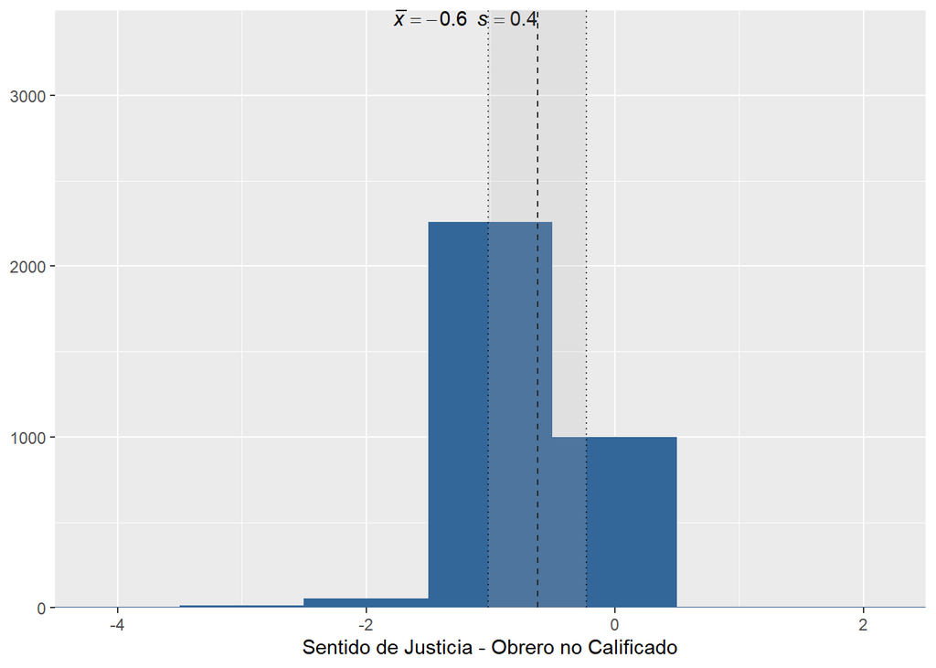

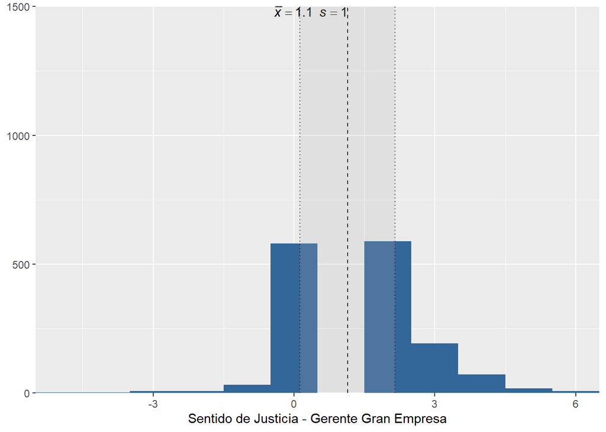

Sentido de Justicia - Gerente Gran Empresa (x) # total N=3417 valid N=3238 mean=2.80 sd=0.58

## Value | N | Raw % | Valid % | Cum. %

Justo | 282 | 8.25 | 8.71 | 8.71 Subrecompensado | 73 | 2.14 | 2.25 | 10.96 Sobrerecompensado | 2883 | 84.37 | 89.04 | 100.00 | 179 | 5.24 | | Sentido de Justicia - Obrero no Calificado (x) # total N=3417 valid N=3344 mean=1.98 sd=0.18

## Value | N | Raw % | Valid % | Cum. %

Justo | 85 | 2.49 | 2.54 | 2.54 Subrecompensado | 3233 | 94.62 | 96.68 | 99.22 Sobrerecompensado | 26 | 0.76 | 0.78 | 100.00 | 73 | 2.14 | |

## Grupos Desaventajados: Ingresos

### Descriptivo

| var | label | n | NA.prc | mean | sd | range |
| --- | --- | --- | --- | --- | --- | --- |
| dd | dd | 2129 | 37.69388 | 509831.1 | 584119.7 | 15000999 (-999-1.5e+07) |

|  | Overall (N=3417) |
| --- | --- |
| ingreso |  |
| Mean (SD) | 510000 (584000) |
| Median [Min, Max] | 400000 [-999, 15000000] |
| Missing | 1288 (37.7%) |

### Recodificación

### Descriptivo final

| var | label | n | NA.prc | mean | sd | range |
| --- | --- | --- | --- | --- | --- | --- |
| dd | Ingreso del entrevistado | 2014 | 41.05941 | 538995.5 | 587310.3 | 14980000 (20000-1.5e+07) |

|  | Overall (N=3417) |
| --- | --- |
| Ingreso del entrevistado |  |
| Mean (SD) | 539000 (587000) |
| Median [Min, Max] | 400000 [20000, 15000000] |
| Missing | 1403 (41.1%) |

## Grupos Desaventajados: Ingresos tramos

Ingreso mensual del entrevistado (en tramos) (2019) (x) # total N=3417 valid N=107 mean=-177.94 sd=393.01

## Value | Label | N | Raw % | Valid % | Cum. %

-999 | No Responde (no leer) | 19 | 0.56 | 17.76 | 17.76 -888 | No Sabe (no leer) | 1 | 0.03 | 0.93 | 18.69 1 | Menos de $40.000 mensuales liquidos | 4 | 0.12 | 3.74 | 22.43 2 | De $40.001 a $85.000 mensuales liquidos | 3 | 0.09 | 2.80 | 25.23 3 | De $85.001 a $125.000 mensuales liquidos | 2 | 0.06 | 1.87 | 27.10 4 | De $125.001 a $170.000 mensuales liquidos | 6 | 0.18 | 5.61 | 32.71 5 | De $170.001 a $210.000 mensuales liquidos | 8 | 0.23 | 7.48 | 40.19 6 | De $210.001 a $230.000 mensuales liquidos | 2 | 0.06 | 1.87 | 42.06 7 | De $230.001 a $280.000 mensuales liquidos | 1 | 0.03 | 0.93 | 42.99 8 | De $280.001 a $320.000 mensuales liquidos | 5 | 0.15 | 4.67 | 47.66 9 | De $320.001 a $360.000 mensuales liquidos | 9 | 0.26 | 8.41 | 56.07 10 | De $360.001 a $400.000 mensuales liquidos | 7 | 0.20 | 6.54 | 62.62 11 | De $400.001 a $465.000 mensuales liquidos | 10 | 0.29 | 9.35 | 71.96 12 | De $465.001 a $540.000 mensuales liquidos | 4 | 0.12 | 3.74 | 75.70 13 | De $540.001 a $665.000 mensuales liquidos | 4 | 0.12 | 3.74 | 79.44 14 | De $665.001 a $850.000 mensuales liquidos | 8 | 0.23 | 7.48 | 86.92 15 | De $850.001 a $1.300.000 mensuales liquidos | 7 | 0.20 | 6.54 | 93.46 16 | Mas de $1.300.001 a mensuales liquidos | 7 | 0.20 | 6.54 | 100.00 | | 3310 | 96.87 | |

### Recodificación

[1] 2221359

### Descriptivo final

Ingreso mensual del entrevistado (en tramos) (2019) (x) # total N=3417 valid N=87 mean=9.53 sd=4.44

## Value | Label | N | Raw % | Valid % | Cum. %

```
1 |         Menos de $40.000 mensuales liquidos |    4 |  0.12 |    4.60 |   4.60
2 |     De $40.001 a $85.000 mensuales liquidos |    3 |  0.09 |    3.45 |   8.05
3 |    De $85.001 a $125.000 mensuales liquidos |    2 |  0.06 |    2.30 |  10.34
4 |   De $125.001 a $170.000 mensuales liquidos |    6 |  0.18 |    6.90 |  17.24
5 |   De $170.001 a $210.000 mensuales liquidos |    8 |  0.23 |    9.20 |  26.44
6 |   De $210.001 a $230.000 mensuales liquidos |    2 |  0.06 |    2.30 |  28.74
7 |   De $230.001 a $280.000 mensuales liquidos |    1 |  0.03 |    1.15 |  29.89
8 |   De $280.001 a $320.000 mensuales liquidos |    5 |  0.15 |    5.75 |  35.63
9 |   De $320.001 a $360.000 mensuales liquidos |    9 |  0.26 |   10.34 |  45.98
```

10 | De $360.001 a $400.000 mensuales liquidos | 7 | 0.20 | 8.05 | 54.02 11 | De $400.001 a $465.000 mensuales liquidos | 10 | 0.29 | 11.49 | 65.52 12 | De $465.001 a $540.000 mensuales liquidos | 4 | 0.12 | 4.60 | 70.11 13 | De $540.001 a $665.000 mensuales liquidos | 4 | 0.12 | 4.60 | 74.71 14 | De $665.001 a $850.000 mensuales liquidos | 8 | 0.23 | 9.20 | 83.91 15 | De $850.001 a $1.300.000 mensuales liquidos | 7 | 0.20 | 8.05 | 91.95 16 | Mas de $1.300.001 a mensuales liquidos | 7 | 0.20 | 8.05 | 100.00 | | 3330 | 97.45 | | Ingreso mensual del entrevistado en tramos (x) # total N=3417 valid N=87 mean=9.53 sd=4.44

## Value | N | Raw % | Valid % | Cum. %

Menos de $40.000 mensuales liquidos | 4 | 0.12 | 4.60 | 4.60 De $40.001 a $85.000 mensuales liquidos | 3 | 0.09 | 3.45 | 8.05 De $85.001 a $125.000 mensuales liquidos | 2 | 0.06 | 2.30 | 10.34 De $125.001 a $170.000 mensuales liquidos | 6 | 0.18 | 6.90 | 17.24 De $170.001 a $210.000 mensuales liquidos | 8 | 0.23 | 9.20 | 26.44 De $210.001 a $230.000 mensuales liquidos | 2 | 0.06 | 2.30 | 28.74 De $230.001 a $280.000 mensuales liquidos | 1 | 0.03 | 1.15 | 29.89 De $280.001 a $320.000 mensuales liquidos | 5 | 0.15 | 5.75 | 35.63 De $320.001 a $360.000 mensuales liquidos | 9 | 0.26 | 10.34 | 45.98 De $360.001 a $400.000 mensuales liquidos | 7 | 0.20 | 8.05 | 54.02 De $400.001 a $465.000 mensuales liquidos | 10 | 0.29 | 11.49 | 65.52 De $465.001 a $540.000 mensuales liquidos | 4 | 0.12 | 4.60 | 70.11 De $540.001 a $665.000 mensuales liquidos | 4 | 0.12 | 4.60 | 74.71 De $665.001 a $850.000 mensuales liquidos | 8 | 0.23 | 9.20 | 83.91 De $850.001 a $1.300.000 mensuales liquidos | 7 | 0.20 | 8.05 | 91.95 Mas de $1.300.001 a mensuales liquidos | 7 | 0.20 | 8.05 | 100.00 | 3330 | 97.45 | |

## Just Dist: Ingreso justo

**NOTA:** Esta variable se usará para construir una variable de sentido de justicia donde el *Observador* y el *Premiado* son la misma persona.

### Descriptivo

| var | label | n | NA.prc | mean | sd | range |
| --- | --- | --- | --- | --- | --- | --- |
| dd | dd | 2129 | 37.69388 | 808688.6 | 745314.8 | 15000999 (-999-1.5e+07) |

|  | Overall (N=3417) |
| --- | --- |
| ingreso_justo |  |
| Mean (SD) | 809000 (745000) |
| Median [Min, Max] | 600000 [-999, 15000000] |
| Missing | 1288 (37.7%) |

### Recodificación

### Descriptivo final

| var | label | n | NA.prc | mean | sd | range |
| --- | --- | --- | --- | --- | --- | --- |
| dd | Ingreso justo del entrevistado | 2083 | 39.04009 | 826567 | 743617.3 | 14997000 (3000-1.5e+07) |

|  | Overall (N=3417) |
| --- | --- |
| Ingreso justo del entrevistado |  |
| Mean (SD) | 827000 (744000) |
| Median [Min, Max] | 600000 [3000, 15000000] |
| Missing | 1334 (39.0%) |

|  | Overall (N=3417) |
| --- | --- |
| Ingreso del entrevistado |  |
| Mean (SD) | 540000 (586000) |
| Median [Min, Max] | 400000 [20000, 15000000] |
| Missing | 1316 (38.5%) |
| Ingreso justo del entrevistado |  |
| Mean (SD) | 827000 (744000) |
| Median [Min, Max] | 600000 [3000, 15000000] |
| Missing | 1334 (39.0%) |

|  | Overall (N=3417) |
| --- | --- |
| Sentido de Justicia - Obrero no Calificado |  |
| Mean (SD) | -0.621 (0.395) |
| Median [Min, Max] | -0.539 [-4.22, 2.48] |
| Missing | 73 (2.1%) |
| Sentido de Justicia - Gerente Gran Empresa |  |
| Mean (SD) | 1.14 (1.02) |
| Median [Min, Max] | 0.916 [-5.30, 6.21] |
| Missing | 179 (5.2%) |
| Sentido de justicia entrevistado |  |
| Mean (SD) | -0.491 (0.406) |
| Median [Min, Max] | -0.424 [-3.40, 3.28] |
| Missing | 1349 (39.5%) |

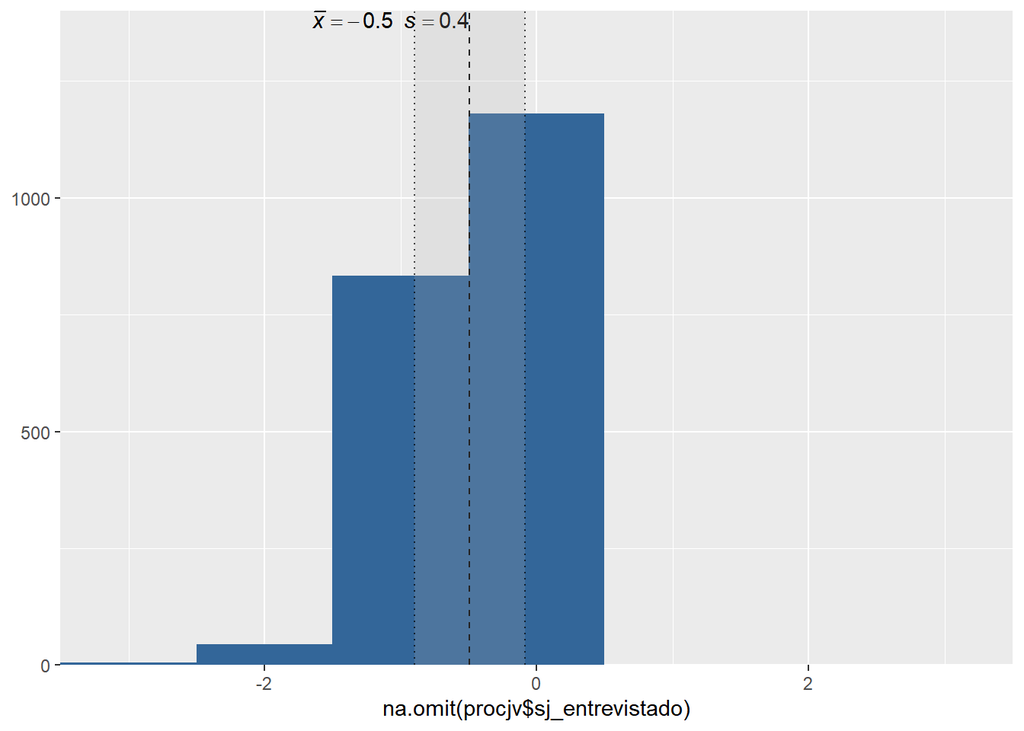

Sentido de justicia entrevistado (x) # total N=3417 valid N=2068 mean=1.90 sd=0.32

## Value | N | Raw % | Valid % | Cum. %

Justo | 214 | 6.26 | 10.35 | 10.35 Subrecompensado | 1838 | 53.79 | 88.88 | 99.23 Sobrerecompensado | 16 | 0.47 | 0.77 | 100.00 | 1349 | 39.48 | |

## Grupos desaventajados: Satisfacción con los ingresos

### Descriptivo

Satisfaccion con ingreso (2019) (x) # total N=3417 valid N=2129 mean=0.82 sd=41.06

## Value | Label | N | Raw % | Valid % | Cum. %

-999 | No Responde (no leer) | 2 | 0.06 | 0.09 | 0.09 -888 | No Sabe (no leer) | 2 | 0.06 | 0.09 | 0.19 1 | Totalmente insatisfecho | 212 | 6.20 | 9.96 | 10.15 2 | Insatisfecho | 1002 | 29.32 | 47.06 | 57.21 3 | Ni satisfecho ni insatisfecho | 381 | 11.15 | 17.90 | 75.11 4 | Satisfecho | 486 | 14.22 | 22.83 | 97.93 5 | Totalmente satisfecho | 44 | 1.29 | 2.07 | 100.00 | | 1288 | 37.69 | |

### Descriptivo final

Satisfaccion con ingreso (2019) (x) # total N=3417 valid N=2125 mean=2.60 sd=1.01

## Value | Label | N | Raw % | Valid % | Cum. %

```
1 |       Totalmente insatisfecho |  212 |  6.20 |    9.98 |   9.98
2 |                  Insatisfecho | 1002 | 29.32 |   47.15 |  57.13
3 | Ni satisfecho ni insatisfecho |  381 | 11.15 |   17.93 |  75.06
4 |                    Satisfecho |  486 | 14.22 |   22.87 |  97.93
5 |         Totalmente satisfecho |   44 |  1.29 |    2.07 | 100.00
```

| | 1292 | 37.81 | | Satisfacción con los ingresos (x) # total N=3417 valid N=2125 mean=2.60 sd=1.01

## Value | N | Raw % | Valid % | Cum. %

Totalmente insatisfecho | 212 | 6.20 | 9.98 | 9.98 Insatisfecho | 1002 | 29.32 | 47.15 | 57.13 Ni satisfecho ni insatisfecho | 381 | 11.15 | 17.93 | 75.06 Satisfecho | 486 | 14.22 | 22.87 | 97.93 Totalmente satisfecho | 44 | 1.29 | 2.07 | 100.00 | 1292 | 37.81 | |

## Grupos Desaventajados: Nivel educacional

### Descriptivo

Nivel educacional (2019) (x) # total N=3417 valid N=3417 mean=4.08 sd=34.42

## Value | Label | N | Raw % | Valid % | Cum. %

-999 | No Responde (no leer) | 4 | 0.12 | 0.12 | 0.12 -888 | No Sabe (no leer) | 0 | 0.00 | 0.00 | 0.12 1 | Sin estudios | 35 | 1.02 | 1.02 | 1.14 2 | Educacion Basica o Preparatoria incompleta | 445 | 13.02 | 13.02 | 14.16 3 | Educacion Basica o Preparatoria completa | 301 | 8.81 | 8.81 | 22.97 4 | Educacion Media o Humanidades incompleta | 453 | 13.26 | 13.26 | 36.23 5 | Educacion Media o Humanidades completa | 979 | 28.65 | 28.65 | 64.88 6 | Tecnica Superior incompleta | 138 | 4.04 | 4.04 | 68.92 7 | Tecnica Superior completa | 422 | 12.35 | 12.35 | 81.27 8 | Universitaria incompleta | 210 | 6.15 | 6.15 | 87.42 9 | Universitaria completa | 375 | 10.97 | 10.97 | 98.39 10 | Estudios de posgrado (magister o doctorado) | 55 | 1.61 | 1.61 | 100.00 | | 0 | 0.00 | |

### Descriptivo final

Nivel educacional (2019) (x) # total N=3417 valid N=3413 mean=5.25 sd=2.24

## Value | Label | N | Raw % | Valid % | Cum. %

```
1 |                                Sin estudios |  35 |  1.02 |    1.03 |   1.03
2 |  Educacion Basica o Preparatoria incompleta | 445 | 13.02 |   13.04 |  14.06
3 |    Educacion Basica o Preparatoria completa | 301 |  8.81 |    8.82 |  22.88
4 |    Educacion Media o Humanidades incompleta | 453 | 13.26 |   13.27 |  36.16
5 |      Educacion Media o Humanidades completa | 979 | 28.65 |   28.68 |  64.84
6 |                 Tecnica Superior incompleta | 138 |  4.04 |    4.04 |  68.88
7 |                   Tecnica Superior completa | 422 | 12.35 |   12.36 |  81.25
8 |                    Universitaria incompleta | 210 |  6.15 |    6.15 |  87.40
9 |                      Universitaria completa | 375 | 10.97 |   10.99 |  98.39
```

10 | Estudios de posgrado (magister o doctorado) | 55 | 1.61 | 1.61 | 100.00 | | 4 | 0.12 | | Nivel educacional del entrevistado (x) # total N=3417 valid N=3413 mean=5.25 sd=2.24

## Value | N | Raw % | Valid % | Cum. %

Sin estudios | 35 | 1.02 | 1.03 | 1.03 Educacion Basica o Preparatoria incompleta | 445 | 13.02 | 13.04 | 14.06 Educacion Basica o Preparatoria completa | 301 | 8.81 | 8.82 | 22.88 Educacion Media o Humanidades incompleta | 453 | 13.26 | 13.27 | 36.16 Educacion Media o Humanidades completa | 979 | 28.65 | 28.68 | 64.84 Tecnica Superior incompleta | 138 | 4.04 | 4.04 | 68.88 Tecnica Superior completa | 422 | 12.35 | 12.36 | 81.25 Universitaria incompleta | 210 | 6.15 | 6.15 | 87.40 Universitaria completa | 375 | 10.97 | 10.99 | 98.39 Estudios de posgrado (magister o doctorado) | 55 | 1.61 | 1.61 | 100.00 | 4 | 0.12 | | Nivel educacional CINE (x) # total N=3417 valid N=3413 mean=3.17 sd=1.24

## Value | Label | N | Raw % | Valid % | Cum. %

```
1 |  Primaria incompleta menos |  480 | 14.05 |   14.06 |  14.06
2 | Primaria y secundaria baja |  301 |  8.81 |    8.82 |  22.88
3 |            Secundaria alta | 1432 | 41.91 |   41.96 |  64.84
4 |      Terciaria ciclo corto |  560 | 16.39 |   16.41 |  81.25
5 |      Terciaria y Postgrado |  640 | 18.73 |   18.75 | 100.00
```

| | 4 | 0.12 | | Nivel educacional CINE 11 (x) # total N=3417 valid N=3413 mean=3.17 sd=1.24

## Value | N | Raw % | Valid % | Cum. %

Primaria incompleta menos | 480 | 14.05 | 14.06 | 14.06 Primaria y secundaria baja | 301 | 8.81 | 8.82 | 22.88 Secundaria alta | 1432 | 41.91 | 41.96 | 64.84 Terciaria ciclo corto | 560 | 16.39 | 16.41 | 81.25 Terciaria y Postgrado | 640 | 18.73 | 18.75 | 100.00 | 4 | 0.12 | |

## Grupos Desaventajados: Sexo

### Descriptivo

Sexo del entrevistado (2019) (x) # total N=3417 valid N=3417 mean=1.62 sd=0.48

## Value | Label | N | Raw % | Valid % | Cum. %

```
1 | Hombre | 1282 | 37.52 |   37.52 |  37.52
2 |  Mujer | 2135 | 62.48 |   62.48 | 100.00
```

| | 0 | 0.00 | |

### Recodificación

### Desriptivo final

Sexo del entrevistado (2019) (x) # total N=3417 valid N=3417 mean=1.62 sd=0.48

## Value | Label | N | Raw % | Valid % | Cum. %

```
1 | Hombre | 1282 | 37.52 |   37.52 |  37.52
2 |  Mujer | 2135 | 62.48 |   62.48 | 100.00
```

| | 0 | 0.00 | | Sexo del entrevistado (x) # total N=3417 valid N=3417 mean=1.62 sd=0.48

## Value | N | Raw % | Valid % | Cum. %

Hombre | 1282 | 37.52 | 37.52 | 37.52 Mujer | 2135 | 62.48 | 62.48 | 100.00 | 0 | 0.00 | |

## Grupos Desaventajados: Pertenencia a Pueblos indigenas

### Descriptivo

Pertenencia a pueblo indigena (2019) (x) # total N=3417 valid N=3417 mean=-1.44 sd=98.19

## Value | Label | N | Raw % | Valid % | Cum. %

-999 | No Responde (no leer) | 9 | 0.26 | 0.26 | 0.26 -888 | No Sabe (no leer) | 30 | 0.88 | 0.88 | 1.14 1 | Mapuche | 304 | 8.90 | 8.90 | 10.04 2 | Aimara | 17 | 0.50 | 0.50 | 10.54 3 | Rapa Nui | 1 | 0.03 | 0.03 | 10.56 4 | Likan Antai | 0 | 0.00 | 0.00 | 10.56 5 | Quechua | 6 | 0.18 | 0.18 | 10.74 6 | Colla | 11 | 0.32 | 0.32 | 11.06 7 | Diaguita | 39 | 1.14 | 1.14 | 12.20 8 | Kawesqar | 0 | 0.00 | 0.00 | 12.20 9 | Yagan o Yamana | 2 | 0.06 | 0.06 | 12.26 10 | Ninguno | 2990 | 87.50 | 87.50 | 99.77 11 | Otro | 8 | 0.23 | 0.23 | 100.00 | | 0 | 0.00 | |

### Recodificación

### Desriptivo final

Pertenencia a pueblo indigena (2019) (x) # total N=3417 valid N=3378 mean=9.09 sd=2.65

## Value | Label | N | Raw % | Valid % | Cum. %

```
1 |        Mapuche |  304 |  8.90 |    9.00 |   9.00
2 |         Aimara |   17 |  0.50 |    0.50 |   9.50
3 |       Rapa Nui |    1 |  0.03 |    0.03 |   9.53
4 |    Likan Antai |    0 |  0.00 |    0.00 |   9.53
5 |        Quechua |    6 |  0.18 |    0.18 |   9.71
6 |          Colla |   11 |  0.32 |    0.33 |  10.04
7 |       Diaguita |   39 |  1.14 |    1.15 |  11.19
8 |       Kawesqar |    0 |  0.00 |    0.00 |  11.19
9 | Yagan o Yamana |    2 |  0.06 |    0.06 |  11.25
```

10 | Ninguno | 2990 | 87.50 | 88.51 | 99.76 11 | Otro | 8 | 0.23 | 0.24 | 100.00 | | 39 | 1.14 | | Pertenencia a grupos desaventajados (x) # total N=3417 valid N=3378 mean=1.20 sd=0.59

## Value | N | Raw % | Valid % | Cum. %

Ninguno | 2990 | 87.50 | 88.51 | 88.51 Otro pueblo | 84 | 2.46 | 2.49 | 91.00 Mapuche | 304 | 8.90 | 9.00 | 100.00 | 39 | 1.14 | |

## Ideología: Sociedad Ideal (SDO)

### Descriptivo

Grado de acuerdo: Sociedad grupos superiores e inferiores (2019) (x) # total N=3417 valid N=3417 mean=-7.64 sd=95.33

## Value | Label | N | Raw % | Valid % | Cum. %

-999 | No Responde (no leer) | 6 | 0.18 | 0.18 | 0.18 -888 | No Sabe (no leer) | 32 | 0.94 | 0.94 | 1.11 1 | Totalmente en desacuerdo | 535 | 15.66 | 15.66 | 16.77 2 | En desacuerdo | 1515 | 44.34 | 44.34 | 61.11 3 | Ni de acuerdo ni en desacuerdo | 649 | 18.99 | 18.99 | 80.10 4 | De acuerdo | 599 | 17.53 | 17.53 | 97.63 5 | Totalmente de acuerdo | 81 | 2.37 | 2.37 | 100.00 | | 0 | 0.00 | |

### Recodificación

### Descriptivo final

Grado de acuerdo: Sociedad grupos superiores e inferiores (2019) (x) # total N=3417 valid N=3379 mean=2.46 sd=1.03

## Value | Label | N | Raw % | Valid % | Cum. %

```
1 |       Totalmente en desacuerdo |  535 | 15.66 |   15.83 |  15.83
2 |                  En desacuerdo | 1515 | 44.34 |   44.84 |  60.67
3 | Ni de acuerdo ni en desacuerdo |  649 | 18.99 |   19.21 |  79.88
4 |                     De acuerdo |  599 | 17.53 |   17.73 |  97.60
5 |          Totalmente de acuerdo |   81 |  2.37 |    2.40 | 100.00
```

| | 38 | 1.11 | | SDO: Sociedad ideal requiere grupos superiores e inferiores (x) # total N=3417 valid N=3379 mean=2.46 sd=1.03

## Value | N | Raw % | Valid % | Cum. %

Totalmente en desacuerdo | 535 | 15.66 | 15.83 | 15.83 En desacuerdo | 1515 | 44.34 | 44.84 | 60.67 Ni de acuerdo ni en desacuerdo | 649 | 18.99 | 19.21 | 79.88 De acuerdo | 599 | 17.53 | 17.73 | 97.60 Totalmente de acuerdo | 81 | 2.37 | 2.40 | 100.00 | 38 | 1.11 | |

## Ideología: Grupos Inferiores (SDO)

### Descriptivo

Grado de acuerdo: Hay grupos de personas inferiores (2019) (x) # total N=3417 valid N=3417 mean=-5.85 sd=88.26

## Value | Label | N | Raw % | Valid % | Cum. %

-999 | No Responde (no leer) | 7 | 0.20 | 0.20 | 0.20 -888 | No Sabe (no leer) | 25 | 0.73 | 0.73 | 0.94 1 | Totalmente en desacuerdo | 491 | 14.37 | 14.37 | 15.31 2 | En desacuerdo | 1253 | 36.67 | 36.67 | 51.98 3 | Ni de acuerdo ni en desacuerdo | 472 | 13.81 | 13.81 | 65.79 4 | De acuerdo | 1058 | 30.96 | 30.96 | 96.75 5 | Totalmente de acuerdo | 111 | 3.25 | 3.25 | 100.00 | | 0 | 0.00 | |

### Recodificación

### Descriptivo final

Grado de acuerdo: Hay grupos de personas inferiores (2019) (x) # total N=3417 valid N=3385 mean=2.72 sd=1.15

## Value | Label | N | Raw % | Valid % | Cum. %

```
1 |       Totalmente en desacuerdo |  491 | 14.37 |   14.51 |  14.51
2 |                  En desacuerdo | 1253 | 36.67 |   37.02 |  51.52
3 | Ni de acuerdo ni en desacuerdo |  472 | 13.81 |   13.94 |  65.47
4 |                     De acuerdo | 1058 | 30.96 |   31.26 |  96.72
5 |          Totalmente de acuerdo |  111 |  3.25 |    3.28 | 100.00
```

| | 32 | 0.94 | | x # total N=3417 valid N=3385 mean=2.72 sd=1.15

## Value | N | Raw % | Valid % | Cum. %

Totalmente en desacuerdo | 491 | 14.37 | 14.51 | 14.51 En desacuerdo | 1253 | 36.67 | 37.02 | 51.52 Ni de acuerdo ni en desacuerdo | 472 | 13.81 | 13.94 | 65.47 De acuerdo | 1058 | 30.96 | 31.26 | 96.72 Totalmente de acuerdo | 111 | 3.25 | 3.28 | 100.00 | 32 | 0.94 | |

## Ideología: Oportunidades Iguales (SDO)

### Descriptivo

Grado de acuerdo: Dar a todos las mismas oportunidades (2019) (x) # total N=3417 valid N=3417 mean=0.96 sd=55.63

## Value | Label | N | Raw % | Valid % | Cum. %

-999 | No Responde (no leer) | 5 | 0.15 | 0.15 | 0.15 -888 | No Sabe (no leer) | 7 | 0.20 | 0.20 | 0.35 1 | Totalmente en desacuerdo | 16 | 0.47 | 0.47 | 0.82 2 | En desacuerdo | 75 | 2.19 | 2.19 | 3.01 3 | Ni de acuerdo ni en desacuerdo | 108 | 3.16 | 3.16 | 6.18 4 | De acuerdo | 2034 | 59.53 | 59.53 | 65.70 5 | Totalmente de acuerdo | 1172 | 34.30 | 34.30 | 100.00 | | 0 | 0.00 | |

### Recodificación

### Descriptivo final

NULL NULL

## Ideología: Condiciones iguales (SDO)

### Descriptivo

Grado de acuerdo: Igualar condiciones diferentes grupos (2019) (x) # total N=3417 valid N=3417 mean=0.43 sd=59.64

## Value | Label | N | Raw % | Valid % | Cum. %

-999 | No Responde (no leer) | 5 | 0.15 | 0.15 | 0.15 -888 | No Sabe (no leer) | 9 | 0.26 | 0.26 | 0.41 1 | Totalmente en desacuerdo | 8 | 0.23 | 0.23 | 0.64 2 | En desacuerdo | 63 | 1.84 | 1.84 | 2.49 3 | Ni de acuerdo ni en desacuerdo | 131 | 3.83 | 3.83 | 6.32 4 | De acuerdo | 2065 | 60.43 | 60.43 | 66.75 5 | Totalmente de acuerdo | 1136 | 33.25 | 33.25 | 100.00 | | 0 | 0.00 | |

### Recodificación

### Descriptivo final

Grado de acuerdo: Igualar condiciones diferentes grupos (2019) (x) # total N=3417 valid N=3403 mean=4.25 sd=0.64

## Value | Label | N | Raw % | Valid % | Cum. %

```
1 |       Totalmente en desacuerdo |    8 |  0.23 |    0.24 |   0.24
2 |                  En desacuerdo |   63 |  1.84 |    1.85 |   2.09
3 | Ni de acuerdo ni en desacuerdo |  131 |  3.83 |    3.85 |   5.94
4 |                     De acuerdo | 2065 | 60.43 |   60.68 |  66.62
5 |          Totalmente de acuerdo | 1136 | 33.25 |   33.38 | 100.00
```

| | 14 | 0.41 | | x # total N=3417 valid N=3403 mean=4.25 sd=0.64

## Value | N | Raw % | Valid % | Cum. %

Totalmente en desacuerdo | 8 | 0.23 | 0.24 | 0.24 En desacuerdo | 63 | 1.84 | 1.85 | 2.09 Ni de acuerdo ni en desacuerdo | 131 | 3.83 | 3.85 | 5.94 De acuerdo | 2065 | 60.43 | 60.68 | 66.62 Totalmente de acuerdo | 1136 | 33.25 | 33.38 | 100.00 | 14 | 0.41 | |

## Ideología: Gobierno firme (RWA)

### Descriptivo

Grado de acuerdo: Necesitamos un gobierno firme (2019) (x) # total N=3417 valid N=3417 mean=-4.42 sd=83.34

## Value | Label | N | Raw % | Valid % | Cum. %

-999 | No Responde (no leer) | 8 | 0.23 | 0.23 | 0.23 -888 | No Sabe (no leer) | 20 | 0.59 | 0.59 | 0.82 1 | Totalmente en desacuerdo | 390 | 11.41 | 11.41 | 12.23 2 | En desacuerdo | 843 | 24.67 | 24.67 | 36.90 3 | Ni de acuerdo ni en desacuerdo | 473 | 13.84 | 13.84 | 50.75 4 | De acuerdo | 1254 | 36.70 | 36.70 | 87.45 5 | Totalmente de acuerdo | 429 | 12.55 | 12.55 | 100.00 | | 0 | 0.00 | |

### Recodificación

### Descriptivo final

Grado de acuerdo: Necesitamos un gobierno firme (2019) (x) # total N=3417 valid N=3389 mean=3.14 sd=1.25

## Value | Label | N | Raw % | Valid % | Cum. %

```
1 |       Totalmente en desacuerdo |  390 | 11.41 |   11.51 |  11.51
2 |                  En desacuerdo |  843 | 24.67 |   24.87 |  36.38
3 | Ni de acuerdo ni en desacuerdo |  473 | 13.84 |   13.96 |  50.34
4 |                     De acuerdo | 1254 | 36.70 |   37.00 |  87.34
5 |          Totalmente de acuerdo |  429 | 12.55 |   12.66 | 100.00
```

| | 28 | 0.82 | | x # total N=3417 valid N=3389 mean=3.14 sd=1.25

## Value | N | Raw % | Valid % | Cum. %

Totalmente en desacuerdo | 390 | 11.41 | 11.51 | 11.51 En desacuerdo | 843 | 24.67 | 24.87 | 36.38 Ni de acuerdo ni en desacuerdo | 473 | 13.84 | 13.96 | 50.34 De acuerdo | 1254 | 36.70 | 37.00 | 87.34 Totalmente de acuerdo | 429 | 12.55 | 12.66 | 100.00 | 28 | 0.82 | |

## Ideología: Mandatario fuerte (RWA)

### Descriptivo

Grado de acuerdo: Pais necesita un mandatario fuerte (2019) (x) # total N=3417 valid N=3417 mean=-7.62 sd=101.38

## Value | Label | N | Raw % | Valid % | Cum. %

-999 | No Responde (no leer) | 14 | 0.41 | 0.41 | 0.41 -888 | No Sabe (no leer) | 27 | 0.79 | 0.79 | 1.20 1 | Totalmente en desacuerdo | 227 | 6.64 | 6.64 | 7.84 2 | En desacuerdo | 513 | 15.01 | 15.01 | 22.86 3 | Ni de acuerdo ni en desacuerdo | 448 | 13.11 | 13.11 | 35.97 4 | De acuerdo | 1619 | 47.38 | 47.38 | 83.35 5 | Totalmente de acuerdo | 569 | 16.65 | 16.65 | 100.00 | | 0 | 0.00 | |

### Recodificación

### Descriptivo final

Grado de acuerdo: Pais necesita un mandatario fuerte (2019) (x) # total N=3417 valid N=3376 mean=3.53 sd=1.14

## Value | Label | N | Raw % | Valid % | Cum. %

```
1 |       Totalmente en desacuerdo |  227 |  6.64 |    6.72 |   6.72
2 |                  En desacuerdo |  513 | 15.01 |   15.20 |  21.92
3 | Ni de acuerdo ni en desacuerdo |  448 | 13.11 |   13.27 |  35.19
4 |                     De acuerdo | 1619 | 47.38 |   47.96 |  83.15
5 |          Totalmente de acuerdo |  569 | 16.65 |   16.85 | 100.00
```

| | 41 | 1.20 | | Grado de acuerdo: Pais necesita un mandatario fuerte (2019) (x) # total N=3417 valid N=3376 mean=3.53 sd=1.14

## Value | Label | N | Raw % | Valid % | Cum. %

```
1 |       Totalmente en desacuerdo |  227 |  6.64 |    6.72 |   6.72
2 |                  En desacuerdo |  513 | 15.01 |   15.20 |  21.92
3 | Ni de acuerdo ni en desacuerdo |  448 | 13.11 |   13.27 |  35.19
4 |                     De acuerdo | 1619 | 47.38 |   47.96 |  83.15
5 |          Totalmente de acuerdo |  569 | 16.65 |   16.85 | 100.00
```

| | 41 | 1.20 | |

## Ideología: Valores niños (RWA)

### Descriptivo

Grado de acuerdo: Obediencia y respeto para los ninnios (2019) (x) # total N=3417 valid N=3417 mean=-0.99 sd=64.78

## Value | Label | N | Raw % | Valid % | Cum. %

-999 | No Responde (no leer) | 8 | 0.23 | 0.23 | 0.23 -888 | No Sabe (no leer) | 8 | 0.23 | 0.23 | 0.47 1 | Totalmente en desacuerdo | 209 | 6.12 | 6.12 | 6.58 2 | En desacuerdo | 644 | 18.85 | 18.85 | 25.43 3 | Ni de acuerdo ni en desacuerdo | 484 | 14.16 | 14.16 | 39.60 4 | De acuerdo | 1567 | 45.86 | 45.86 | 85.46 5 | Totalmente de acuerdo | 497 | 14.54 | 14.54 | 100.00 | | 0 | 0.00 | |

### Recodificación

### Descriptivo final

Grado de acuerdo: Obediencia y respeto para los ninnios (2019) (x) # total N=3417 valid N=3401 mean=3.44 sd=1.13

## Value | Label | N | Raw % | Valid % | Cum. %

```
1 |       Totalmente en desacuerdo |  209 |  6.12 |    6.15 |   6.15
2 |                  En desacuerdo |  644 | 18.85 |   18.94 |  25.08
3 | Ni de acuerdo ni en desacuerdo |  484 | 14.16 |   14.23 |  39.31
4 |                     De acuerdo | 1567 | 45.86 |   46.07 |  85.39
5 |          Totalmente de acuerdo |  497 | 14.54 |   14.61 | 100.00
```

| | 16 | 0.47 | | x # total N=3417 valid N=3401 mean=3.44 sd=1.13

## Value | N | Raw % | Valid % | Cum. %

Totalmente en desacuerdo | 209 | 6.12 | 6.15 | 6.15 En desacuerdo | 644 | 18.85 | 18.94 | 25.08 Ni de acuerdo ni en desacuerdo | 484 | 14.16 | 14.23 | 39.31 De acuerdo | 1567 | 45.86 | 46.07 | 85.39 Totalmente de acuerdo | 497 | 14.54 | 14.61 | 100.00 | 16 | 0.47 | |

## Ideología: Obediencia y disciplina (RWA)

### Descriptivo

Grado de acuerdo: Obediencia y disciplina para buena vida (2019) (x) # total N=3417 valid N=3417 mean=-0.02 sd=57.63

## Value | Label | N | Raw % | Valid % | Cum. %

-999 | No Responde (no leer) | 5 | 0.15 | 0.15 | 0.15 -888 | No Sabe (no leer) | 8 | 0.23 | 0.23 | 0.38 1 | Totalmente en desacuerdo | 166 | 4.86 | 4.86 | 5.24 2 | En desacuerdo | 546 | 15.98 | 15.98 | 21.22 3 | Ni de acuerdo ni en desacuerdo | 481 | 14.08 | 14.08 | 35.29 4 | De acuerdo | 1727 | 50.54 | 50.54 | 85.84 5 | Totalmente de acuerdo | 484 | 14.16 | 14.16 | 100.00 | | 0 | 0.00 | |

### Recodificación

### Descriptivo final

NULL x # total N=3417 valid N=3404 mean=3.53 sd=1.07

## Value | N | Raw % | Valid % | Cum. %

Totalmente en desacuerdo | 166 | 4.86 | 4.88 | 4.88 En desacuerdo | 546 | 15.98 | 16.04 | 20.92 Ni de acuerdo ni en desacuerdo | 481 | 14.08 | 14.13 | 35.05 De acuerdo | 1727 | 50.54 | 50.73 | 85.78 Totalmente de acuerdo | 484 | 14.16 | 14.22 | 100.00 | 13 | 0.38 | |

## Just. Proc: Trato respetuoso en servicios de salud

### Descriptivo

Frecuencia: Trato respetuoso en servicios de salud a [CLASE] (2019) (x) # total N=3417 valid N=1250 mean=1.58 sd=35.64

## Value | Label | N | Raw % | Valid % | Cum. %

-999 | No Responde (no leer) | 0 | 0.00 | 0.00 | 0.00 -888 | No Sabe (no leer) | 2 | 0.06 | 0.16 | 0.16 1 | Nunca | 132 | 3.86 | 10.56 | 10.72 2 | Casi nunca | 217 | 6.35 | 17.36 | 28.08 3 | A veces | 524 | 15.34 | 41.92 | 70.00 4 | Casi siempre | 256 | 7.49 | 20.48 | 90.48 5 | Siempre | 119 | 3.48 | 9.52 | 100.00 | | 2167 | 63.42 | |

### Recodificación

### Descriptivo final

Frecuencia: Trato respetuoso en servicios de salud a [CLASE] (2019) (x) # total N=3417 valid N=1248 mean=3.01 sd=1.09

## Value | Label | N | Raw % | Valid % | Cum. %

```
1 |        Nunca |  132 |  3.86 |   10.58 |  10.58
2 |   Casi nunca |  217 |  6.35 |   17.39 |  27.96
3 |      A veces |  524 | 15.34 |   41.99 |  69.95
4 | Casi siempre |  256 |  7.49 |   20.51 |  90.46
5 |      Siempre |  119 |  3.48 |    9.54 | 100.00
```

| | 2169 | 63.48 | | Trato respetuoso en servicios de salud (x) # total N=3417 valid N=1248 mean=3.01 sd=1.09

## Value | N | Raw % | Valid % | Cum. %

Nunca | 132 | 3.86 | 10.58 | 10.58 Casi nunca | 217 | 6.35 | 17.39 | 27.96 A veces | 524 | 15.34 | 41.99 | 69.95 Casi siempre | 256 | 7.49 | 20.51 | 90.46 Siempre | 119 | 3.48 | 9.54 | 100.00 | 2169 | 63.48 | |

## Just. Porc. Trato respetuoso carabineros

### Descriptivo

Frecuencia: Trato respetuoso por Carabineros a [CLASE] (2019) (x) # total N=3417 valid N=1250 mean=-7.75 sd=97.06

## Value | Label | N | Raw % | Valid % | Cum. %

-999 | No Responde (no leer) | 0 | 0.00 | 0.00 | 0.00 -888 | No Sabe (no leer) | 15 | 0.44 | 1.20 | 1.20 1 | Nunca | 187 | 5.47 | 14.96 | 16.16 2 | Casi nunca | 208 | 6.09 | 16.64 | 32.80 3 | A veces | 472 | 13.81 | 37.76 | 70.56 4 | Casi siempre | 221 | 6.47 | 17.68 | 88.24 5 | Siempre | 147 | 4.30 | 11.76 | 100.00 | | 2167 | 63.42 | | NULL

### Recodificación

### Descriptivo final

Frecuencia: Trato respetuoso por Carabineros a [CLASE] (2019) (x) # total N=3417 valid N=1235 mean=2.95 sd=1.19

## Value | Label | N | Raw % | Valid % | Cum. %

```
1 |        Nunca |  187 |  5.47 |   15.14 |  15.14
2 |   Casi nunca |  208 |  6.09 |   16.84 |  31.98
3 |      A veces |  472 | 13.81 |   38.22 |  70.20
4 | Casi siempre |  221 |  6.47 |   17.89 |  88.10
5 |      Siempre |  147 |  4.30 |   11.90 | 100.00
```

| | 2182 | 63.86 | | Trato respetuoso por parte de carabineros (x) # total N=3417 valid N=1235 mean=2.95 sd=1.19

## Value | N | Raw % | Valid % | Cum. %

Nunca | 187 | 5.47 | 15.14 | 15.14 Casi nunca | 208 | 6.09 | 16.84 | 31.98 A veces | 472 | 13.81 | 38.22 | 70.20 Casi siempre | 221 | 6.47 | 17.89 | 88.10 Siempre | 147 | 4.30 | 11.90 | 100.00 | 2182 | 63.86 | |

## Control Exp: Edad del entrevistado

### Descriptivo

| var | label | n | NA.prc | mean | sd | range |
| --- | --- | --- | --- | --- | --- | --- |
| dd | Edad del entrevistado (2019) | 3417 | 0 | 48.77085 | 15.41705 | 73 (19-92) |

|  | Overall (N=3417) |
| --- | --- |
| Edad del entrevistado (2019) |  |
| Mean (SD) | 48.8 (15.4) |
| Median [Min, Max] | 49.0 [19.0, 92.0] |

### Recodificación

### Descriptivo final

| var | label | n | NA.prc | mean | sd | range |
| --- | --- | --- | --- | --- | --- | --- |
| dd | Edad del entrevistado (2019) | 3417 | 0 | 48.77085 | 15.41705 | 73 (19-92) |

|  | Overall (N=3417) |
| --- | --- |
| Edad del entrevistado (2019) |  |
| Mean (SD) | 48.8 (15.4) |
| Median [Min, Max] | 49.0 [19.0, 92.0] |

## Control Exp: Posición política

### Descriptivo

Autoubicacion escala izquierda-derecha (2019) (x) # total N=3417 valid N=3417 mean=-1.72 sd=91.01

## Value | Label | N | Raw % | Valid % | Cum. %

-999 | No Responde (no leer) | 6 | 0.18 | 0.18 | 0.18 -888 | No Sabe (no leer) | 28 | 0.82 | 0.82 | 1.00 0 | 0 Izquierda | 199 | 5.82 | 5.82 | 6.82 1 | 1 | 56 | 1.64 | 1.64 | 8.46 2 | 2 | 109 | 3.19 | 3.19 | 11.65 3 | 3 | 183 | 5.36 | 5.36 | 17.00 4 | 4 | 198 | 5.79 | 5.79 | 22.80 5 | 5 Centro | 915 | 26.78 | 26.78 | 49.58 6 | 6 | 128 | 3.75 | 3.75 | 53.32 7 | 7 | 62 | 1.81 | 1.81 | 55.14 8 | 8 | 104 | 3.04 | 3.04 | 58.18 9 | 9 | 18 | 0.53 | 0.53 | 58.71 10 | 10 Derecha | 138 | 4.04 | 4.04 | 62.75 11 | 11 Independiente (no leer) | 70 | 2.05 | 2.05 | 64.79 12 | 12 Ninguno (no leer) | 1203 | 35.21 | 35.21 | 100.00 | | 0 | 0.00 | |

### Recodificación

### Descriptivo final

Autoubicacion escala izquierda-derecha (2019) (x) # total N=3417 valid N=3383 mean=7.38 sd=4.04

## Value | Label | N | Raw % | Valid % | Cum. %

```
0 |                0 Izquierda |  199 |  5.82 |    5.88 |   5.88
1 |                          1 |   56 |  1.64 |    1.66 |   7.54
2 |                          2 |  109 |  3.19 |    3.22 |  10.76
3 |                          3 |  183 |  5.36 |    5.41 |  16.17
4 |                          4 |  198 |  5.79 |    5.85 |  22.02
5 |                   5 Centro |  915 | 26.78 |   27.05 |  49.07
6 |                          6 |  128 |  3.75 |    3.78 |  52.85
7 |                          7 |   62 |  1.81 |    1.83 |  54.69
8 |                          8 |  104 |  3.04 |    3.07 |  57.76
9 |                          9 |   18 |  0.53 |    0.53 |  58.29
```

10 | 10 Derecha | 138 | 4.04 | 4.08 | 62.37 11 | 11 Independiente (no leer) | 70 | 2.05 | 2.07 | 64.44 12 | 12 Ninguno (no leer) | 1203 | 35.21 | 35.56 | 100.00 | | 34 | 1.00 | | NULL

## Control Exp: Frecuencia participación marchas

### Descriptivo

Frecuencia: Asiste a marcha pacifica (2019) (x) # total N=3417 valid N=3417 mean=0.98 sd=22.92

## Value | Label | N | Raw % | Valid % | Cum. %

-999 | No Responde (no leer) | 1 | 0.03 | 0.03 | 0.03 -888 | No Sabe (no leer) | 1 | 0.03 | 0.03 | 0.06 1 | Nunca | 2541 | 74.36 | 74.36 | 74.42 2 | Casi nunca | 241 | 7.05 | 7.05 | 81.47 3 | A veces | 386 | 11.30 | 11.30 | 92.77 4 | Frecuentemente | 173 | 5.06 | 5.06 | 97.83 5 | Muy frecuentemente | 74 | 2.17 | 2.17 | 100.00 | | 0 | 0.00 | |

### Recodificación

### Descriptivo final

Frecuencia: Asiste a marcha pacifica (2019) (x) # total N=3417 valid N=3415 mean=1.54 sd=1.02

## Value | Label | N | Raw % | Valid % | Cum. %

```
1 |              Nunca | 2541 | 74.36 |   74.41 |  74.41
2 |         Casi nunca |  241 |  7.05 |    7.06 |  81.46
3 |            A veces |  386 | 11.30 |   11.30 |  92.77
4 |     Frecuentemente |  173 |  5.06 |    5.07 |  97.83
5 | Muy frecuentemente |   74 |  2.17 |    2.17 | 100.00
```

| | 2 | 0.06 | | Frecuencia de participación en marchas (últimos 12 meses) (x) # total N=3417 valid N=3415 mean=1.54 sd=1.02

## Value | N | Raw % | Valid % | Cum. %

Nunca | 2541 | 74.36 | 74.41 | 74.41 Casi nunca | 241 | 7.05 | 7.06 | 81.46 A veces | 386 | 11.30 | 11.30 | 92.77 Frecuentemente | 173 | 5.06 | 5.07 | 97.83 Muy frecuentemente | 74 | 2.17 | 2.17 | 100.00 | 2 | 0.06 | |

## Control Exp: Confianza en carabineros

### Descriptivo

Grado de confianza: Carabineros (2019) (x) # total N=3417 valid N=3417 mean=0.25 sd=44.46

## Value | Label | N | Raw % | Valid % | Cum. %

-999 | No Responde (no leer) | 2 | 0.06 | 0.06 | 0.06 -888 | No Sabe (no leer) | 6 | 0.18 | 0.18 | 0.23 1 | Nada | 1106 | 32.37 | 32.37 | 32.60 2 | Poca | 781 | 22.86 | 22.86 | 55.46 3 | Algo | 801 | 23.44 | 23.44 | 78.90 4 | Bastante | 499 | 14.60 | 14.60 | 93.50 5 | Mucha | 222 | 6.50 | 6.50 | 100.00 | | 0 | 0.00 | |

### Recodificación

### Descriptivo final

Grado de confianza: Carabineros (2019) (x) # total N=3417 valid N=3409 mean=2.40 sd=1.25

## Value | Label | N | Raw % | Valid % | Cum. %

```
1 |     Nada | 1106 | 32.37 |   32.44 |  32.44
2 |     Poca |  781 | 22.86 |   22.91 |  55.35
3 |     Algo |  801 | 23.44 |   23.50 |  78.85
4 | Bastante |  499 | 14.60 |   14.64 |  93.49
5 |    Mucha |  222 |  6.50 |    6.51 | 100.00
```

| | 8 | 0.23 | | Confianza en carabineros (x) # total N=3417 valid N=3409 mean=2.40 sd=1.25

## Value | N | Raw % | Valid % | Cum. %

Nada | 1106 | 32.37 | 32.44 | 32.44 Poca | 781 | 22.86 | 22.91 | 55.35 Algo | 801 | 23.44 | 23.50 | 78.85 Bastante | 499 | 14.60 | 14.64 | 93.49 Mucha | 222 | 6.50 | 6.51 | 100.00 | 8 | 0.23 | |

# Guardar base de datos general